# Pertemuan 6&7

Megawati Roito Panjaitan

2023-10-16

## Packages

```r
library(ggplot2)
library(tsibble)
library(tseries)
library(MASS)
library(forecast)
library(TSA)
library(TTR)
library(aTSA)
library(graphics)
library(rio)
```

## Impor data

```r
data <- import("https://raw.githubusercontent.com/panjaitanroito/Praktikum-MPDW/main/Pertemuan%2067/data1.csv")
head(data)
```

```
##   Period  Value
## 1      1 268044
## 2      2 272020
## 3      3 275192
## 4      4 271046
## 5      5 271394
## 6      6 273422
```

```r
str(data)
```

```
## 'data.frame':    240 obs. of  2 variables:
##  $ Period: int  1 2 3 4 5 6 7 8 9 10 ...
##  $ Value : int  268044 272020 275192 271046 271394 273422 272630 272918 277548 276927 ...
```

```r
data<-data$Value
data.ts<-ts(data)
```

Deskripsi data: Dataset berisi perkiraan penjualan retail dan jasa makanan bulanan di AS menurut jenis usaha dari tahun 2000-2019. Data perkiraan ditampilkan di kolom “Value” dalam satuan juta dolar.

### Eksplorasi Data

Sebelum masuk dalam tahap pemodelan, dilakukan eksplorasi data dengan plot deret waktu untuk melihat pola data.

#### Plot data penuh

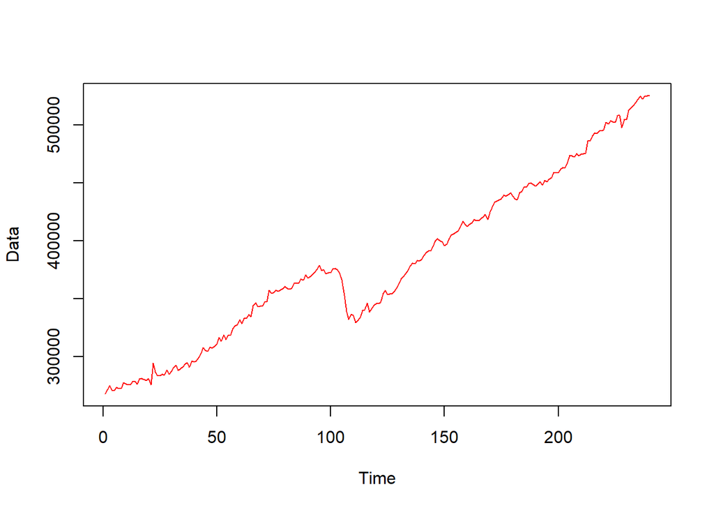

```r
plot.ts(data.ts,
     col = "red",
     lty=1,
     xlab = "Time",
     ylab = "Data")
```

Plot deret waktu di atas menunjukkan bahwa data tidak stasioner dalam rataan, ditandai dengan data yang memiliki pola tren.

#### Uji Kestasioneran Data

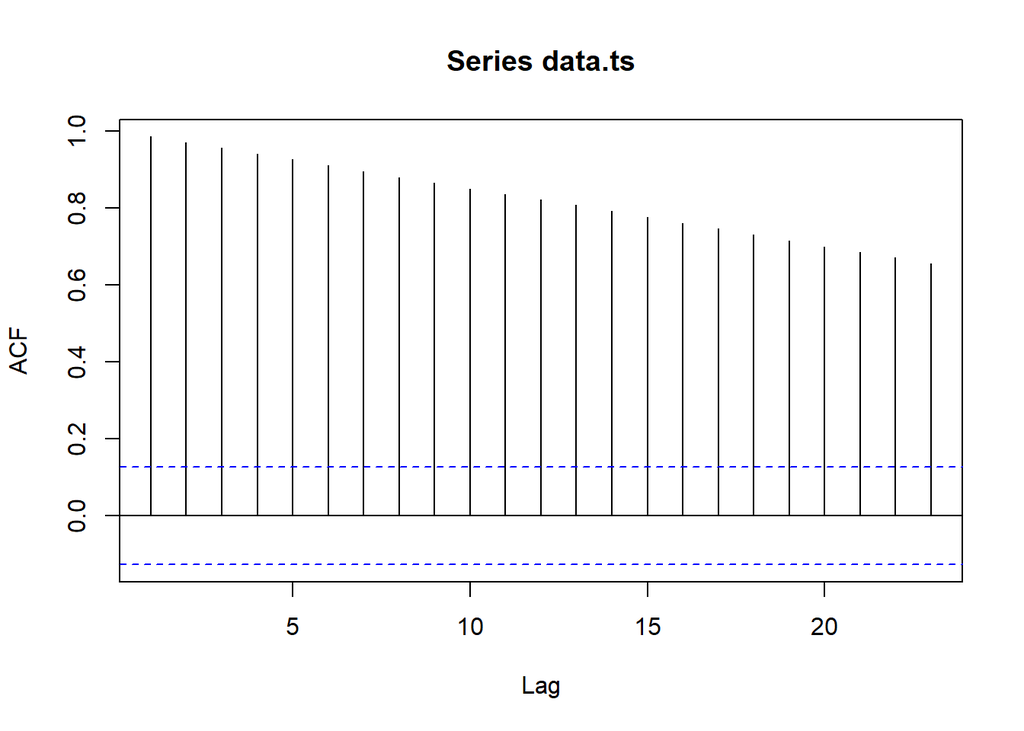

```r
acf(data.ts)
```

```r
tseries::adf.test(data.ts)
```

```
##
##  Augmented Dickey-Fuller Test
##
## data:  data.ts
## Dickey-Fuller = -1.721, Lag order = 6, p-value = 0.6932
## alternative hypothesis: stationary
```

Berdasarkan plot ACF, terlihat bahwa plot ACF pada data tersebut cenderung tails off slowly sehingga berdasarkan plot ACF data tidak stasioner dalam rataan.

$H_0$ : Data tidak stasioner dalam rataan $H_1$ : Data stasioner dalam rataan

Berdasarkan uji ADF tersebut, didapat p-value sebesar 0.6932 yang lebih besar dari taraf nyata 5% sehingga tak tolak H0 dan menandakan bahwa data tidak stasioner dalam rataan. Hal ini sesuai dengan hasil eksplorasi menggunakan plot time series dan plot ACF.

### Plot data latih

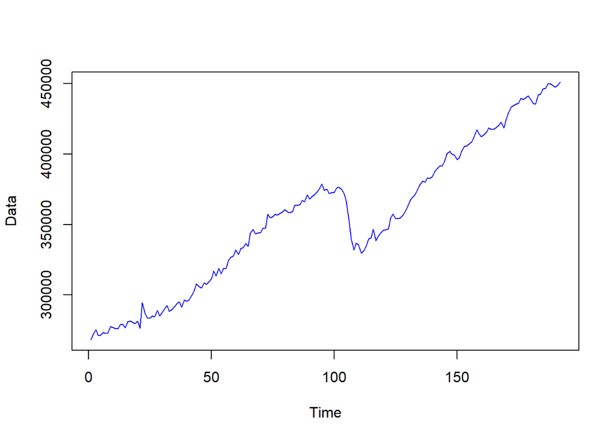

```r
data.train<-data[1:192]
train.ts<-ts(data.train)
plot.ts(train.ts,
        col = "blue",
        lty = 1,
        xlab = "Time",
        ylab = "Data")
```

Plot deret waktu di atas menunjukkan bahwa data latih tidak stasioner dalam rataan, ditandai dengan data yang memiliki pola tren naik.

### Plot data uji

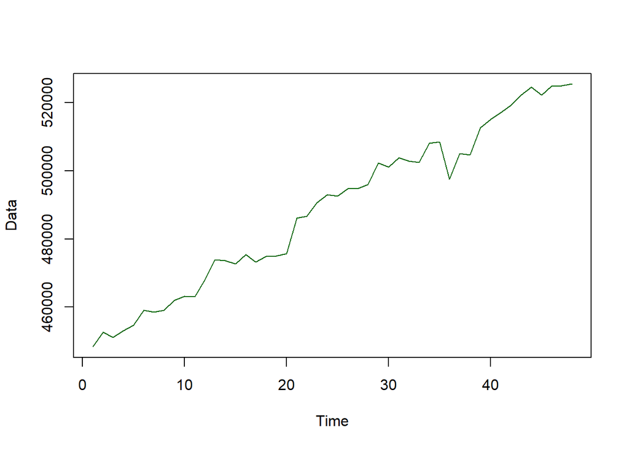

```r
data.test<-data[193:240]
test.ts<-ts(data.test)
plot.ts(test.ts,
        col = "darkgreen",
        lty = 1,
        xlab = "Time",
        ylab = "Data")
```

#### Uji Kestasioneran Data Train

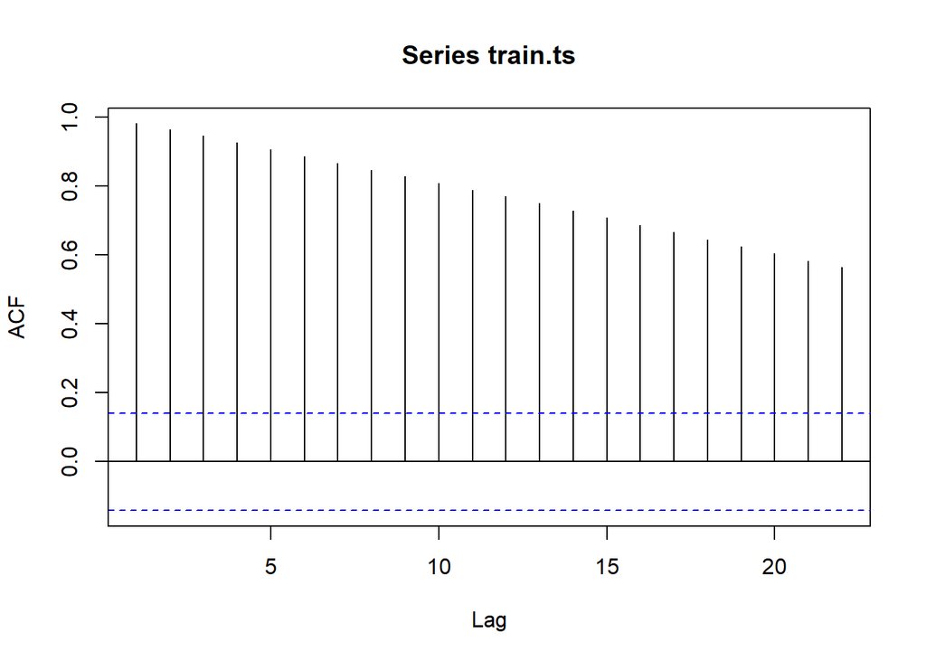

```r
acf(train.ts)
```

```r
tseries::adf.test(train.ts)
```

```
##
##  Augmented Dickey-Fuller Test
##
## data:  train.ts
## Dickey-Fuller = -1.9226, Lag order = 5, p-value = 0.6085
## alternative hypothesis: stationary
```

Berdasarkan plot ACF, terlihat bahwa plot ACF pada data train tersebut cenderung tails off slowly sehingga berdasarkan plot ACF data tidak stasioner dalam rataan.

$H_0$ : Data tidak stasioner dalam rataan $H_1$ : Data stasioner dalam rataan

Berdasarkan uji ADF tersebut, didapat p-value sebesar 0.6085 yang lebih besar dari taraf nyata 5% sehingga tak tolak H0 dan menandakan bahwa data tidak stasioner dalam rataan. Hal ini sesuai dengan hasil eksplorasi menggunakan plot time series dan plot ACF.

#### Plot Box-Cox

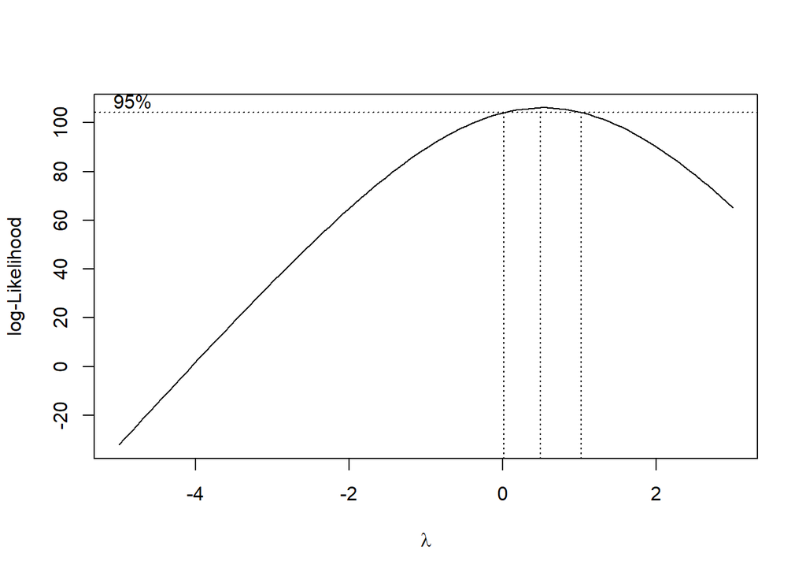

```r
index <- seq(1:192)
bc = boxcox(train.ts~index, lambda = seq(-5,3,by=1))
```

```r
#Nilai Rounded Lambda
lambda <- bc$x[which.max(bc$y)]
lambda
```

```
## [1] 0.4949495
```

```r
#SK
bc$x[bc$y > max(bc$y) - 1/2 * qchisq(.95,1)]
```

```
##  [1] 0.09090909 0.17171717 0.25252525 0.33333333 0.41414141 0.49494949
##  [7] 0.57575758 0.65656566 0.73737374 0.81818182 0.89898990 0.97979798
```

Gambar di atas menunjukkan nilai rounded value (λ ) optimum sebesar 0.4949495 dan pada selang kepercayaan 95% nilai memiliki batas bawah 0.09090909 dan batas atas 0.97979798. Selang tersebut tidak memuat nilai satu sehingga dapat dikatakan bahwa data tidak stasioner dalam ragam.

### Penanganan Ketidakstasioneran Data

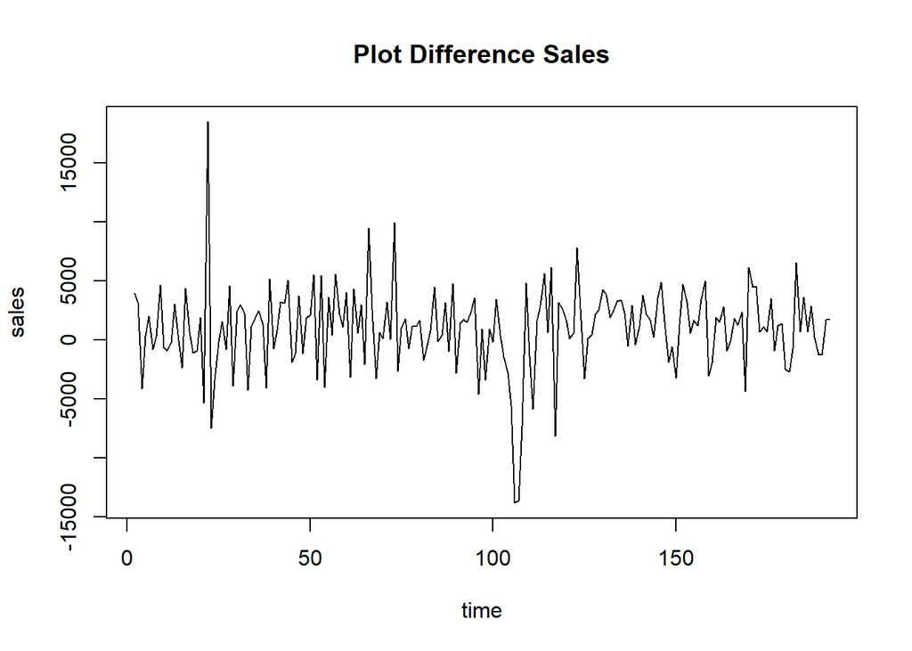

```r
train.diff<-diff(train.ts,differences = 1)
plot.ts(train.diff, lty=1, xlab="time", ylab="sales", main="Plot Difference Sales")
```

#### Uji Kestationeran

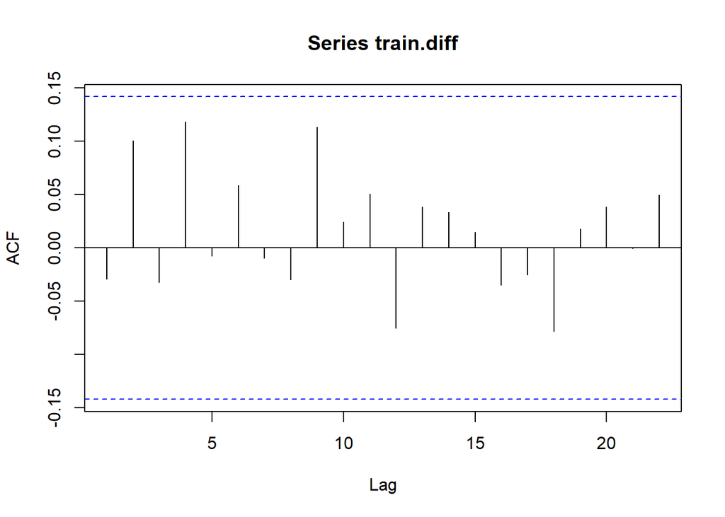

```r
acf(train.diff)
```

```r
tseries::adf.test(train.diff)
```

```
##
##  Augmented Dickey-Fuller Test
##
## data:  train.diff
## Dickey-Fuller = -4.7506, Lag order = 5, p-value = 0.01
## alternative hypothesis: stationary
```

Pada plot ACF terlihat bahwa tidak ada garis vertikal di lag tertentu yang melebihi batas garis biru horizontal.

$H_0$ : Data tidak stasioner dalam rataan $H_1$ : Data stasioner dalam rataan

Berdasarkan uji ADF tersebut, didapat p-value sebesar 0.01 yang lebih kecil dari taraf nyata 5% sehingga tolak H0 dan menandakan bahwa data stasioner dalam rataan.

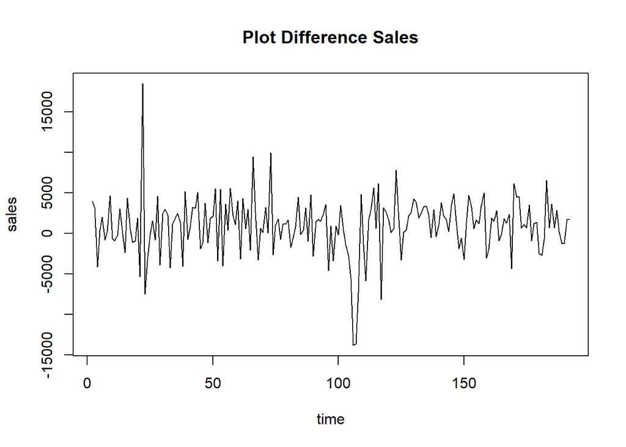

```r
train.diff1<-diff(train.ts,differences = 2)
plot.ts(train.diff, lty=1, xlab="time", ylab="sales", main="Plot Difference Sales")
```

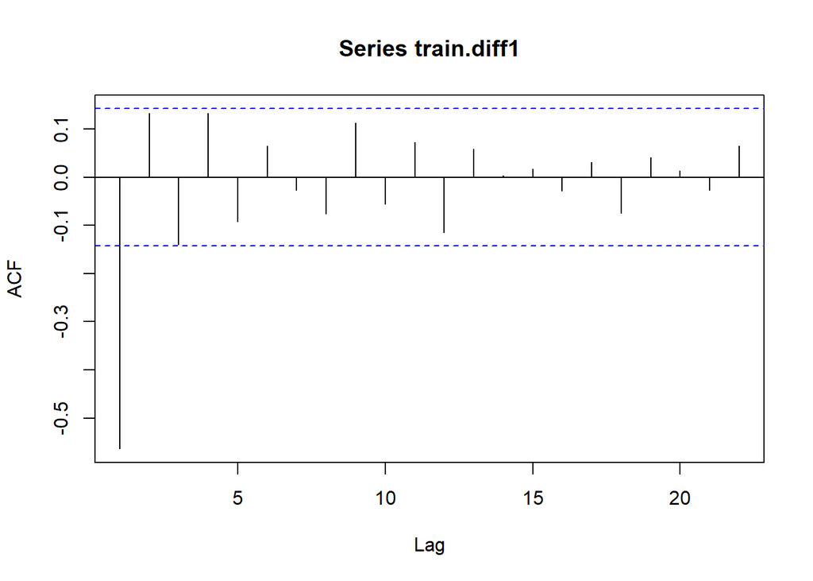

```r
acf(train.diff1)
```

```r
tseries::adf.test(train.diff1)
```

```
##
##  Augmented Dickey-Fuller Test
##
## data:  train.diff1
## Dickey-Fuller = -9.0862, Lag order = 5, p-value = 0.01
## alternative hypothesis: stationary
```

Berdasarkan plot tersebut, terlihat bahwa plot ACF cuts off pada lag ke 1. Hal ini menandakan data sudah stasioner dalam rataan dan ketidakstasioneran data telah berhasil tertangani.

$H_0$ : Data tidak stasioner dalam rataan $H_1$ : Data stasioner dalam rataan

Berdasarkan uji ADF tersebut, didapat p-value sebesar 0.01 yang lebih kecil dari taraf nyata 5% sehingga tolak H0 dan menandakan bahwa data stasioner dalam rataan.

### Identifikasi Model

#### Plot ACF

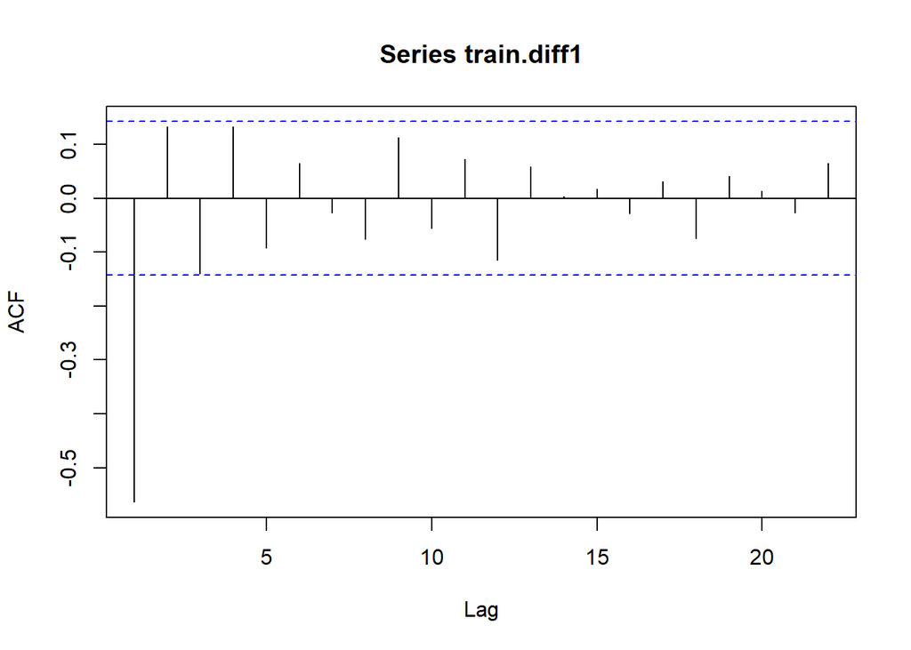

```r
acf(train.diff1)
```

Berdasarkan plot tersebut, terlihat bahwa plot ACF cenderung *cuts off* pada lag ke 1, sehingga jika plot PACF dianggap *tails of*, maka model tentatifnya adalah ARIMA(0,2,1).

#### Plot PACF

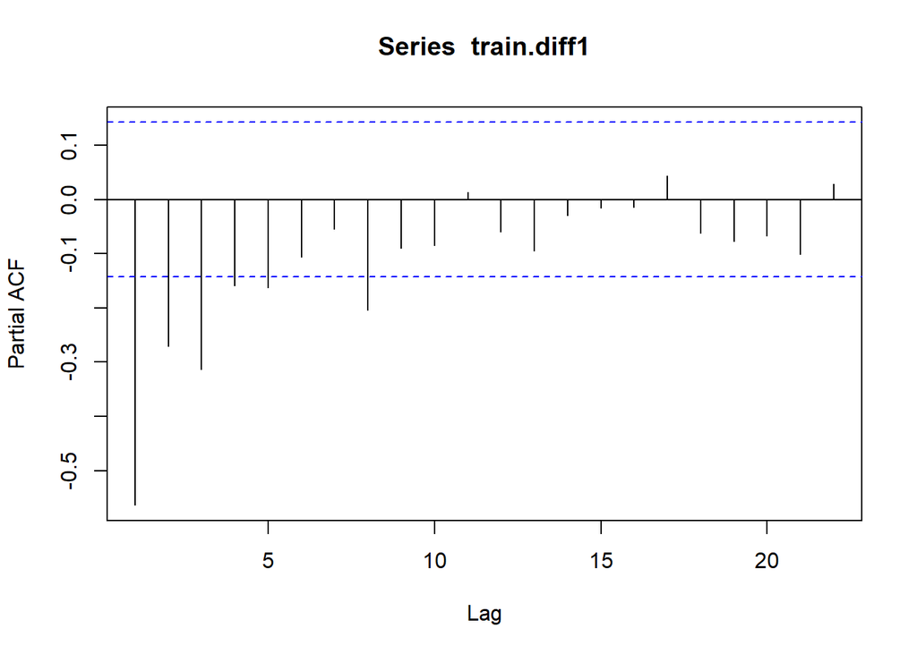

```r
pacf(train.diff1)
```

#### Plot EACF

```r
eacf(train.diff1)
```

```
## AR/MA
##   0 1 2 3 4 5 6 7 8 9 10 11 12 13
## 0 x o o o o o o o o o o  o  o  o
## 1 x x o o o o o o o o o  o  o  o
## 2 x x x o o o o o o o o  o  o  o
## 3 x x o x o o o o o o o  o  o  o
## 4 x x o o x o o o o o o  o  o  o
## 5 x x o o x o o o o o o  o  o  o
## 6 x o x x x x x o o o o  o  o  o
## 7 x x x x x x x o o o o  o  o  o
```

Identifikasi model menggunakan plot EACF dilakukan dengan melihat ujung segitiga pada pola segitiga nol. Dalam hal ini model tentatif yang terbentuk adalah ARIMA(0,2,1), ARIMA(0,2,2) dan ARIMA(1,2,2).

### Pendugaan Parameter Model Tentatif

#### ARIMA(0,2,1)

```r
model1.da=Arima(train.diff1, order=c(0,2,1),method="ML")
summary(model1.da) #AIC=3968.94
```

```
## Series: train.diff1
## ARIMA(0,2,1)
##
## Coefficients:
##           ma1
##       -1.0000
## s.e.   0.0131
##
## sigma^2 = 82611434:  log likelihood = -1982.47
## AIC=3968.94   AICc=3969   BIC=3975.41
##
## Training set error measures:
##                    ME     RMSE      MAE      MPE     MAPE      MASE       ACF1
## Training set 18.75028 9017.042 6333.275 257.2373 604.1494 0.9916352 -0.7190462
```

```r
lmtest::coeftest(model1.da) #seluruh parameter signifikan
```

```
##
## z test of coefficients:
##
##      Estimate Std. Error z value  Pr(>|z|)
## ma1 -1.000000   0.013058 -76.581 < 2.2e-16 ***
## ---
## Signif. codes:  0 '***' 0.001 '**' 0.01 '*' 0.05 '.' 0.1 ' ' 1
```

#### ARIMA(0,2,2)

```r
model2.da=Arima(train.diff1, order=c(0,2,2),method="ML")
summary(model2.da) #AIC=3766.8
```

```
## Series: train.diff1
## ARIMA(0,2,2)
##
## Coefficients:
##           ma1     ma2
##       -1.9935  1.0000
## s.e.   0.0208  0.0192
##
## sigma^2 = 26744438:  log likelihood = -1880.4
## AIC=3766.8   AICc=3766.93   BIC=3776.51
##
## Training set error measures:
##                     ME     RMSE      MAE      MPE     MAPE      MASE       ACF1
## Training set -38.51851 5116.776 3607.308 85.34369 117.7943 0.5648158 -0.5526202
```

```r
lmtest::coeftest(model2.da) #seluruh parameter signifikan
```

```
##
## z test of coefficients:
##
##      Estimate Std. Error z value  Pr(>|z|)
## ma1 -1.993511   0.020788 -95.898 < 2.2e-16 ***
## ma2  0.999952   0.019166  52.173 < 2.2e-16 ***
## ---
## Signif. codes:  0 '***' 0.001 '**' 0.01 '*' 0.05 '.' 0.1 ' ' 1
```

#### ARIMA(1,2,2)

```r
model3.da=Arima(train.diff1, order=c(1,2,2),method="ML")
summary(model3.da) #AIC=3699.74
```

```
## Series: train.diff1
## ARIMA(1,2,2)
##
## Coefficients:
##           ar1      ma1   ma2
##       -0.5546  -1.9978  1.00
## s.e.   0.0602   0.0201  0.02
##
## sigma^2 = 18308916:  log likelihood = -1845.87
## AIC=3699.74   AICc=3699.95   BIC=3712.68
##
## Training set error measures:
##                     ME     RMSE      MAE      MPE     MAPE      MASE       ACF1
## Training set -170.3074 4222.215 3101.394 14.75059 322.4587 0.4856021 -0.1451549
```

```r
lmtest::coeftest(model3.da) #seluruh parameter signifikan
```

```
##
## z test of coefficients:
##
##      Estimate Std. Error  z value  Pr(>|z|)
## ar1 -0.554619   0.060178  -9.2164 < 2.2e-16 ***
## ma1 -1.997750   0.020124 -99.2734 < 2.2e-16 ***
## ma2  0.999968   0.020028  49.9277 < 2.2e-16 ***
## ---
## Signif. codes:  0 '***' 0.001 '**' 0.01 '*' 0.05 '.' 0.1 ' ' 1
```

Berdasarkan pendugaan parameter di atas, nilai AIC terkecil dimiliki oleh model ARIMA(1,2,2).

### Analisis Sisaan

Model terbaik hasil identifikasi kemudian dicek asumsi sisaannya. Sisaan model ARIMA harus memenuhi asumsi normalitas, kebebasan sisaan, dan kehomogenan ragam. Diagnostik model dilakukan secara eksplorasi dan uji formal.

#### Eksplorasi Sisaan

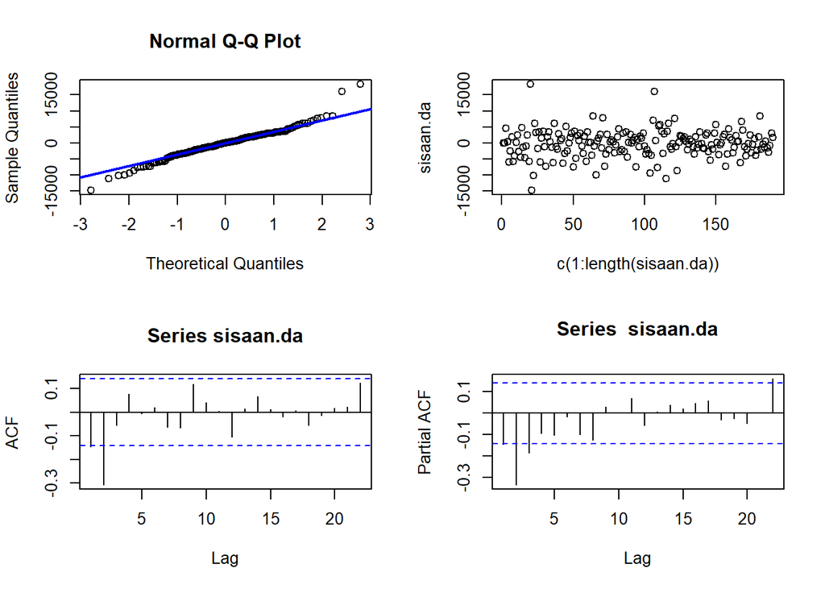

```r
#Eksplorasi
sisaan.da <- model3.da$residuals
par(mfrow=c(2,2))
qqnorm(sisaan.da)
qqline(sisaan.da, col = "blue", lwd = 2)
plot(c(1:length(sisaan.da)),sisaan.da)
acf(sisaan.da)
pacf(sisaan.da)
```

```r
par(mfrow = c(1,1))
```

#### Uji Formal

```r
#1) Sisaan Menyebar Normal
ks.test(sisaan.da,"pnorm")
```

```
##
##  Asymptotic one-sample Kolmogorov-Smirnov test
##
## data:  sisaan.da
## D = 0.50526, p-value < 2.2e-16
## alternative hypothesis: two-sided
```

Selain dengan eksplorasi, asumsi tersebut dapat diuji menggunakan uji formal. Pada tahapan ini uji formal yang digunakan untuk normalitas adalah uji Kolmogorov-Smirnov (KS). Hipotesis pada uji KS adalah sebagai berikut.

$H_0$ : Sisaan menyebar normal

$H_1$ : Sisaan tidak menyebar normal

Berdasarkan uji KS tersebut, didapat *p-value* sebesar < 2.2e-16 yang kurang dari taraf nyata 5% sehingga tolak $H_0$ dan menandakan bahwa sisaan tidak menyebar normal. Hal ini berbeda dengan hasil eksplorasi menggunakan plot kuantil-kuantil normal.

```r
#2) Sisaan saling bebas/tidak ada autokorelasi
Box.test(sisaan.da, type = "Ljung")
```

```
##
##  Box-Ljung test
##
## data:  sisaan.da
## X-squared = 4.0668, df = 1, p-value = 0.04373
```

Selanjutnya akan dilakukan uji formal untuk kebebasan sisaan menggunakan uji Ljung-Box. Hipotesis yang digunakan adalah sebagai berikut.

$H_0$ : Sisaan saling bebas

$H_1$ : Sisaan tidak tidak saling bebas

```r
#3) Sisaan homogen
Box.test((sisaan.da)^2, type = "Ljung")  #tak tolak H0 > sisaan homogen
```

```
##
##  Box-Ljung test
##
## data:  (sisaan.da)^2
## X-squared = 20.606, df = 1, p-value = 5.643e-06
```

Hipotesis yang digunakan untuk uji kehomogenan ragam adalah sebagai berikut.

$H_0$ : Ragam sisaan homogen

$H_1$ : Ragam sisaan tidak homogen

Berdasarkan uji Ljung-Box terhadap sisaan kuadrat tersebut, didapat *p-value* sebesar 5.643e-06 yang kurang dari taraf nyata 5% sehingga tolak $H_0$ dan menandakan bahwa ragam sisaan tidak homogen.

```r
#4) Nilai tengah sisaan sama dengan nol
t.test(sisaan.da, mu = 0, conf.level = 0.95)  #tak tolak h0 > nilai tengah sisaan sama dengan 0
```

```
##
##  One Sample t-test
##
## data:  sisaan.da
## t = -0.55498, df = 189, p-value = 0.5796
## alternative hypothesis: true mean is not equal to 0
## 95 percent confidence interval:
##  -775.6397  435.0249
## sample estimates:
## mean of x
## -170.3074
```

Terakhir, dengan uji-t, akan dicek apakah nilai tengah sisaan sama dengan nol. Hipotesis yang diujikan sebagai berikut.

$H_0$ : nilai tengah sisaan sama dengan 0

$H_1$ : nilai tengah sisaan tidak sama dengan 0

Berdasarkan uji-ttersebut, didapat *p-value* sebesar 0.5796 yang lebih besar dari taraf nyata 5% sehingga tak tolak $H_0$.

### Peramalan

```r
#---FORECAST---#
ramalan.da <- forecast::forecast(model3.da, h = 17)
ramalan.da
```

```
##     Point Forecast     Lo 80    Hi 80      Lo 95     Hi 95
## 193     25.2345299 -5488.695 5539.164  -8407.593  8458.062
## 194      1.9880618 -6267.964 6271.940  -9587.076  9591.052
## 195     11.1762914 -6495.892 6518.244  -9940.525  9962.878
## 196      2.3756075 -6562.209 6566.960 -10037.290 10042.041
## 197      3.5519245 -6587.494 6594.597 -10076.582 10083.686
## 198     -0.8051971 -6594.945 6593.334 -10085.671 10084.061
## 199     -2.0933661 -6600.791 6596.604 -10093.931 10089.744
## 200     -5.0836358 -6603.659 6593.492 -10096.734 10086.567
## 201     -7.1298874 -6607.368 6593.108 -10101.323 10087.063
## 202     -9.6997098 -6610.355 6590.956 -10104.531 10085.131
## 203    -11.9791496 -6613.886 6589.928 -10108.725 10084.767
## 204    -14.4196413 -6617.271 6588.432 -10112.610 10083.770
## 205    -16.7708105 -6620.973 6587.432 -10117.027 10083.485
## 206    -19.1715196 -6624.733 6586.390 -10121.506 10083.163
## 207    -21.5447529 -6628.724 6585.635 -10126.354 10083.264
## 208    -23.9332249 -6632.858 6584.991 -10131.411 10083.544
## 209    -26.3132452 -6637.201 6584.575 -10136.794 10084.168
```

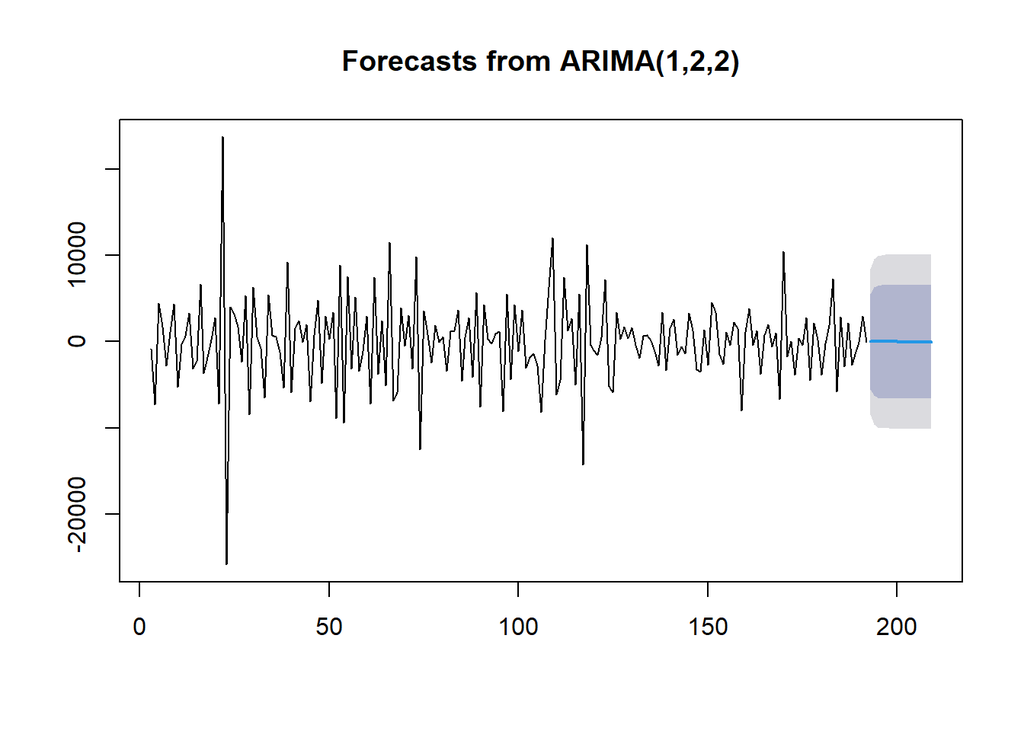

```r
data.ramalan.da <- ramalan.da$mean
plot(ramalan.da)
```

Berdasarkan hasil plot ramalan di atas, dapat dilihat bahwa ramalan ARIMA(1,2,2) cenderung stabil hingga akhir periode. Selanjutnya, dapat dicari nilai akurasi antara hasil ramalan dengan data uji sebagai berikut.

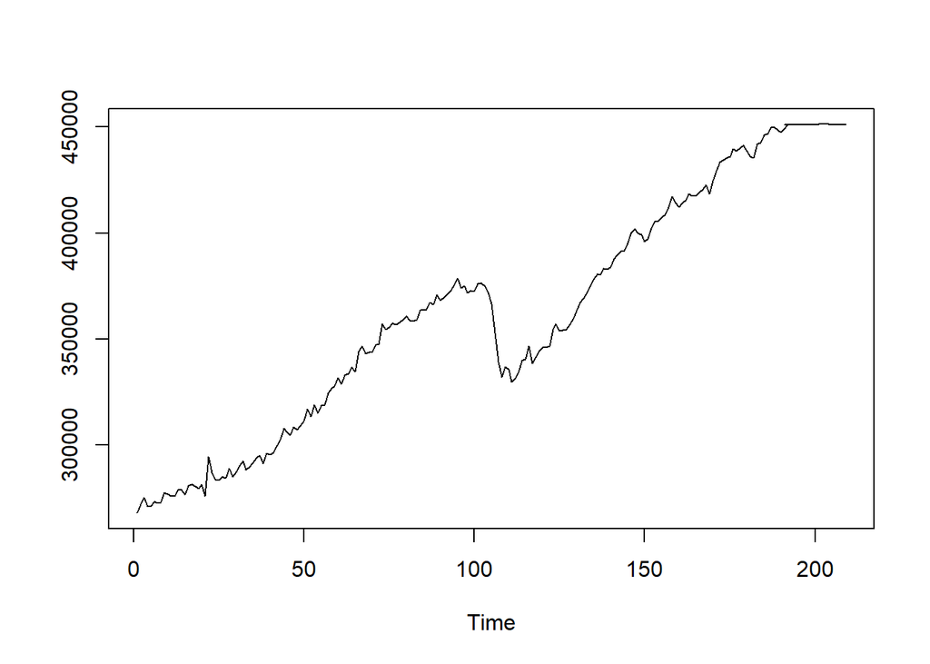

```r
pt_1 <- train.ts[192] #nilai akhir data latih
hasil.forc.Diff <- data.ramalan.da
hasil <- diffinv(hasil.forc.Diff, differences = 2) + pt_1
#has.1 sama hasilnta dengan: cumsum(c(pt_1,hasil.forc.Diff))
ts.plot(train.ts,hasil)
```

```r
perbandingan.da<-matrix(data=c(head(test.ts, n=17), hasil[-1]),
                 nrow = 17, ncol = 2)
colnames(perbandingan.da)<-c("Aktual","Hasil Forecast")
perbandingan.da
```

```
##       Aktual Hasil Forecast
##  [1,] 448325       450978.0
##  [2,] 452555       451003.2
##  [3,] 451132       451030.5
##  [4,] 453034       451068.9
##  [5,] 454683       451109.6
##  [6,] 459088       451154.0
##  [7,] 458579       451197.5
##  [8,] 459022       451238.9
##  [9,] 461893       451275.3
## [10,] 463240       451304.5
## [11,] 462994       451324.0
## [12,] 468076       451331.5
## [13,] 473832       451324.6
## [14,] 473582       451301.0
## [15,] 472693       451258.1
## [16,] 475335       451193.8
## [17,] 473242       451105.5
```

```r
accuracy(ts(hasil[-1]), head(test.ts, n=17))
```

```
##                ME     RMSE      MAE      MPE     MAPE      ACF1 Theil's U
## Test set 11241.55 14165.33 11553.66 2.396812 2.466431 0.8265815  5.072623
```

Dari hasil diperoleh nilai MAPE 2.466431 (sangat akurat) untuk menggambarkan model deret waktu.